# Pfynwald VPD manipulation

Atmosphere part

This report was automaticaly generated. For real-time data please follow the link below. For more questions please contact the authors of the report.

Author

Schaub M., Gissler J., Trotsiuk V., ….

Published

2024-05-31

## Introcuction

In the heart of the Pfynwald forest, our experiment stands at the intersection of climate change research and forest ecology, with a particular focus on impact of VPD on tree growth and mortality. In this report we present the latest scientific summary of main measured parameters in the experiment. Please visit [**Real-Time data**](https://lwfvis.wsl.ch:3000/public-dashboards/31262a55a9f641a0b65224baebabfcc0) for more information and in-depth exploration of historical and recent data.

## Atmospheric precipitation and Solar radiation

Atmospheric precipitation and Solar radiation play a pivotal role in driving tree vitality and growth through the VPD (Vapor pressure deficit) and soil water availability. Understanding where the current year stands in relation to previous year help to make the early warning and alerting. This year, the sum of precipitation recorded thus far is **290** mm, which represents approximately **47 %** of the average total annual precipitation observed over the past years (**622** mm), highlighting the variability and potential shifts in climate patterns affecting our study site. The peak precipitation year within our dataset occurred in **2023**, with a total of **712** mm, underscoring the fluctuating nature of these environmental variables.

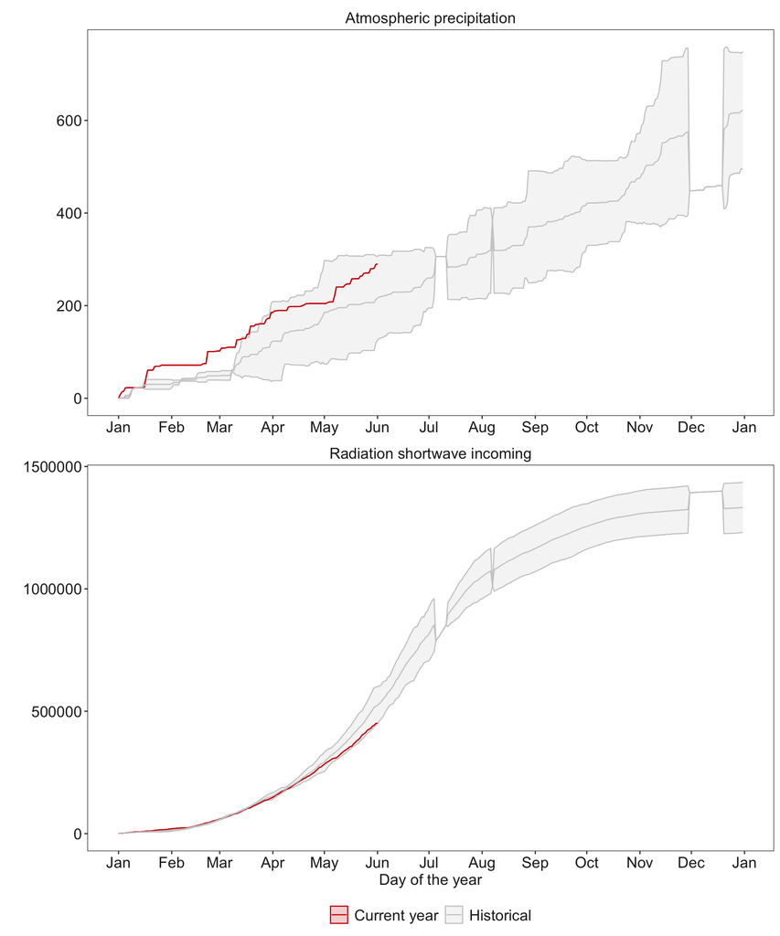